# scaler-clustering

[figure not shown]

## About Scaler 🧑‍💻

Scaler is an online tech-versity offering intensive computer science & Data Science courses through live classes delivered by tech leaders and subject matter experts. The meticulously structured program enhances the skills of software professionals by offering a modern curriculum with exposure to the latest technologies. It is a product by InterviewBit.

### Business Problem 💡

To cluster a segment of learners from the Scaler database based on their job profile, company, and other relevant features, with the goal of profiling the best companies and job positions to work for. The resulting clusters should group learners with similar characteristics.

### Dataset 📊

| Column Name | Description |
| --- | --- |
| `Unnamed 0` | Index of the dataset |
| `Email_hash` | Anonymised Personal Identifiable Information (PII) |
| `Company_hash` | This represents an anonymized identifier for the company, which is the current employer of the learner. |
| `orgyear` | Employment start date |
| `CTC` | Current CTC |
| `Job_position` | Job profile in the company |
| `CTC_updated_year` | Year in which CTC got updated (Yearly increments, Promotions) |

#### Importing Required Libraries 🤝

```python
import pandas as pd
import numpy as np
import re

from scipy import stats
from sklearn.impute import KNNImputer
from sklearn.preprocessing import LabelEncoder, OneHotEncoder, StandardScaler
from sklearn.decomposition import PCA
from sklearn.cluster import KMeans
from sklearn.metrics import silhouette_score
from scipy.cluster.hierarchy import dendrogram, linkage, fcluster

from matplotlib import pyplot as plt
import seaborn as sns

import warnings
warnings.filterwarnings('ignore')
```

```python
palette = ['#0000ff', '#ffffff', '#000000', '#99c2ff']
```

#### Read Dataset 🔍

```python
df = pd.read_csv(r'scaler_clustering.csv', index_col=0)
df.head()
```

|  | company_hash | email_hash | orgyear | ctc | job_position | ctc_updated_year |
| --- | --- | --- | --- | --- | --- | --- |
| 0 | atrgxnnt xzaxv | 6de0a4417d18ab14334c3f43397fc13b30c35149d70c05... | 2016.0 | 1100000 | Other | 2020.0 |
| 1 | qtrxvzwt xzegwgbb rxbxnta | b0aaf1ac138b53cb6e039ba2c3d6604a250d02d5145c10... | 2018.0 | 449999 | FullStack Engineer | 2019.0 |
| 2 | ojzwnvwnxw vx | 4860c670bcd48fb96c02a4b0ae3608ae6fdd98176112e9... | 2015.0 | 2000000 | Backend Engineer | 2020.0 |
| 3 | ngpgutaxv | effdede7a2e7c2af664c8a31d9346385016128d66bbc58... | 2017.0 | 700000 | Backend Engineer | 2019.0 |
| 4 | qxen sqghu | 6ff54e709262f55cb999a1c1db8436cb2055d8f79ab520... | 2017.0 | 1400000 | FullStack Engineer | 2019.0 |

```python
print("Shape of the data: ", df.shape)
print("The Given Dataset has {} rows and {} columns".format(df.shape[0], df.shape[1]))
print("Columns: ", df.columns.to_list())
```

```
Shape of the data:  (205843, 6)
The Given Dataset has 205843 rows and 6 columns
Columns:  ['company_hash', 'email_hash', 'orgyear', 'ctc', 'job_position', 'ctc_updated_year']
```

### Shape 🕵🏽‍♂️

- The dataset comprises 205843 rows and 6 columns, representing a volume of data.
- Each row corresponds to information about the learners details.

### Data Structure 📰

```python
df.describe()
```

|  | orgyear | ctc | ctc_updated_year |
| --- | --- | --- | --- |
| count | 205757.000000 | 2.058430e+05 | 205843.000000 |
| mean | 2014.882750 | 2.271685e+06 | 2019.628231 |
| std | 63.571115 | 1.180091e+07 | 1.325104 |
| min | 0.000000 | 2.000000e+00 | 2015.000000 |
| 25% | 2013.000000 | 5.300000e+05 | 2019.000000 |
| 50% | 2016.000000 | 9.500000e+05 | 2020.000000 |
| 75% | 2018.000000 | 1.700000e+06 | 2021.000000 |
| max | 20165.000000 | 1.000150e+09 | 2021.000000 |

```python
df.describe(include='object')
```

|  | company_hash | email_hash | job_position |
| --- | --- | --- | --- |
| count | 205799 | 205843 | 153279 |
| unique | 37299 | 153443 | 1016 |
| top | nvnv wgzohrnvzwj otqcxwto | bbace3cc586400bbc65765bc6a16b77d8913836cfc98b7... | Backend Engineer |
| freq | 8337 | 10 | 43554 |

```python
df.info()
```

```
<class 'pandas.core.frame.DataFrame'>
Index: 205843 entries, 0 to 206922
Data columns (total 6 columns):
 #   Column            Non-Null Count   Dtype
---  ------            --------------   -----
 0   company_hash      205799 non-null  object
 1   email_hash        205843 non-null  object
 2   orgyear           205757 non-null  float64
 3   ctc               205843 non-null  int64
 4   job_position      153279 non-null  object
 5   ctc_updated_year  205843 non-null  float64
dtypes: float64(2), int64(1), object(3)
memory usage: 11.0+ MB
```

```python
df.isnull().sum()
```

```
company_hash           44
email_hash              0
orgyear                86
ctc                     0
job_position        52564
ctc_updated_year        0
dtype: int64
```

```python
print(df.duplicated().sum())
df.drop_duplicates(inplace=True)
```

```
34
```

### 🕵🏽‍♂️ Dataset Information:

#### Initial Cleanup 🛀

```python
df['job_position'] = df['job_position'].apply(lambda x: re.sub('[^A-Za-z0-9 ]+', '', x.lower()) if isinstance(x, str) else x)
df['company_hash'] = df['company_hash'].apply(lambda x: re.sub('[^A-Za-z0-9 ]+', '', x.lower()) if isinstance(x, str) else x)
df['email_hash'] = df['email_hash'].apply(lambda x: re.sub('[^A-Za-z0-9 ]+', '', x.lower()) if isinstance(x, str) else x)
```

```python
df['orgyear'] = df.groupby(['company_hash'])['orgyear'].transform(lambda x: x.ffill().bfill())
print(df['orgyear'].isnull().sum())
df['orgyear'] = df['orgyear'].fillna(df['orgyear'].mode()[0])
```

```
70
```

```python
# Convert the data types
df['job_position'] = df['job_position'].astype('category')
df['company_hash'] = df['company_hash'].astype('category')
df['email_hash'] = df['email_hash'].astype('category')

df['ctc'] = df['ctc'].astype('int')
df['ctc_updated_year'] = df['ctc_updated_year'].astype('int')
df['orgyear'] = df['orgyear'].astype('int')
```

### Data Observation 👀

```python
df.shape
```

```
(205809, 6)
```

```python
#### Frequency of Email Id and Company Hash
# df.groupby(['email_hash','company_hash']).size().reset_index(name='count').sort_values('count', ascending=False).head()
df[['email_hash', 'company_hash']].value_counts().reset_index(name='count').sort_values('count', ascending=False).head()
```

|  | email_hash | company_hash | count |
| --- | --- | --- | --- |
| 0 | bbace3cc586400bbc65765bc6a16b77d8913836cfc98b7... | oxej ntwyzgrgsxto rxbxnta | 10 |
| 2 | 298528ce3160cc761e4dc37a07337ee2e0589df251d736... | cvrhtbgbtznhb | 9 |
| 3 | 6842660273f70e9aa239026ba33bfe82275d6ab0d20124... | ihvrwgbb | 9 |
| 1 | 3e5e49daa5527a6d5a33599b238bf9bf31e85b9efa9a94... | wgcxvb ntwyzgrgsxto | 9 |
| 4 | c0eb129061675da412b0deb15871dd06ef0d7cd86eb5f7... | nyt a t oyvf sqghu | 8 |

```python
df[df['email_hash'].str.contains('bbace3cc586400bbc65765bc6a16b77d8913836cfc98b7')]
```

|  | company_hash | email_hash | orgyear | ctc | job_position | ctc_updated_year |
| --- | --- | --- | --- | --- | --- | --- |
| 24129 | oxej ntwyzgrgsxto rxbxnta | bbace3cc586400bbc65765bc6a16b77d8913836cfc98b7... | 2018 | 720000 | NaN | 2020 |
| 46038 | oxej ntwyzgrgsxto rxbxnta | bbace3cc586400bbc65765bc6a16b77d8913836cfc98b7... | 2018 | 720000 | support engineer | 2020 |
| 72415 | oxej ntwyzgrgsxto rxbxnta | bbace3cc586400bbc65765bc6a16b77d8913836cfc98b7... | 2018 | 720000 | other | 2020 |
| 103145 | oxej ntwyzgrgsxto rxbxnta | bbace3cc586400bbc65765bc6a16b77d8913836cfc98b7... | 2018 | 720000 | fullstack engineer | 2020 |
| 118076 | oxej ntwyzgrgsxto rxbxnta | bbace3cc586400bbc65765bc6a16b77d8913836cfc98b7... | 2018 | 720000 | data analyst | 2020 |
| 121825 | oxej ntwyzgrgsxto rxbxnta | bbace3cc586400bbc65765bc6a16b77d8913836cfc98b7... | 2018 | 660000 | other | 2019 |
| 124840 | oxej ntwyzgrgsxto rxbxnta | bbace3cc586400bbc65765bc6a16b77d8913836cfc98b7... | 2018 | 660000 | support engineer | 2019 |
| 145021 | oxej ntwyzgrgsxto rxbxnta | bbace3cc586400bbc65765bc6a16b77d8913836cfc98b7... | 2018 | 660000 | fullstack engineer | 2019 |
| 153402 | oxej ntwyzgrgsxto rxbxnta | bbace3cc586400bbc65765bc6a16b77d8913836cfc98b7... | 2018 | 660000 | devops engineer | 2019 |
| 160472 | oxej ntwyzgrgsxto rxbxnta | bbace3cc586400bbc65765bc6a16b77d8913836cfc98b7... | 2018 | 660000 | NaN | 2019 |

```python
df.sort_values(by=['email_hash','company_hash','orgyear','ctc','ctc_updated_year','job_position'], ascending=True, inplace=True)
df['job_position'] = df.groupby(['email_hash', 'company_hash', 'ctc', 'ctc_updated_year'])['job_position'].transform(lambda x: x.ffill().bfill())
```

```python
print(df.duplicated().sum())
df.drop_duplicates(inplace=True)
```

```
27308
```

### 🕵🏽‍♂️ Duplicate value check:

```python
print("No. of Unique Job Positions: ", df['job_position'].nunique())
print("No. of Null in Job Positions: ",df['job_position'].isnull().sum())
```

```
No. of Unique Job Positions:  931
No. of Null in Job Positions:  25332
```

```python
## Manual clean up of job positions

# jobs_df = df['job_position'].value_counts().to_frame()
# jobs_df.reset_index(inplace=True)
# jobs_df.columns = ['job_position', 'count']
# jobs_df.to_csv('job_positions.csv', index=False)

jobs_df = pd.read_csv('job_positions.csv')
jobs_df.head()
```

|  | job_position | count | filler |
| --- | --- | --- | --- |
| 0 | backend engineer | 43551 | Backend Engineer |
| 1 | fullstack engineer | 25975 | Fullstack Engineer |
| 2 | other | 18070 | Others |
| 3 | frontend engineer | 10417 | Frontend Engineer |
| 4 | engineering leadership | 6870 | Technical lead |

```python
job_position_dict = dict(zip(jobs_df['job_position'], jobs_df['filler']))
# job_position_dict
```

```python
df['job_position'] = df['job_position'].map(job_position_dict)
```

```python
print("Null count: ", df['job_position'].isnull().sum())
print("Number of Uniques: ", df['job_position'].nunique())
```

```
Null count:  25335
Number of Uniques:  41
```

```python
# Encode the categorical column
# Temporarily fill NaN values with a placeholder
df['job_position'].fillna('missing', inplace=True)

# Encode the categorical column
le = LabelEncoder()
df['job_position_encoded'] = le.fit_transform(df['job_position'])

# Replace the placeholder back to NaN
df['job_position_encoded'].replace(np.where(le.classes_ == 'missing')[0][0], np.nan, inplace=True)

# Apply KNN imputer
imputer = KNNImputer(n_neighbors=5)
df['job_position_encoded'] = imputer.fit_transform(df[['job_position_encoded']])

# Decode the imputed values back to original categories
df['job_position'] = le.inverse_transform(df['job_position_encoded'].astype(int))


# Drop the encoded column
df.drop(columns=['job_position_encoded'], inplace=True)
```

```python
df.isnull().sum()
```

```
company_hash        39
email_hash           0
orgyear              0
ctc                  0
job_position         0
ctc_updated_year     0
dtype: int64
```

```python
print(df['company_hash'].nunique())
df.dropna(subset=['company_hash'], inplace=True)
```

```
37299
```

```python
df.isnull().sum()
```

```
company_hash        0
email_hash          0
orgyear             0
ctc                 0
job_position        0
ctc_updated_year    0
dtype: int64
```

### Exploratory Data Analysis (EDA) 💹

```python
# CTC Column checks
print(df['ctc'].min(), df['ctc'].max())

# Calculate Percentiles
lower_bound = df['ctc'].quantile(0.01)
upper_bound = df['ctc'].quantile(0.99)

print(f"Lower Bound: {lower_bound}, Upper Bound: {upper_bound}")
```

```
2 1000150000
Lower Bound: 35000.0, Upper Bound: 16000000.0
```

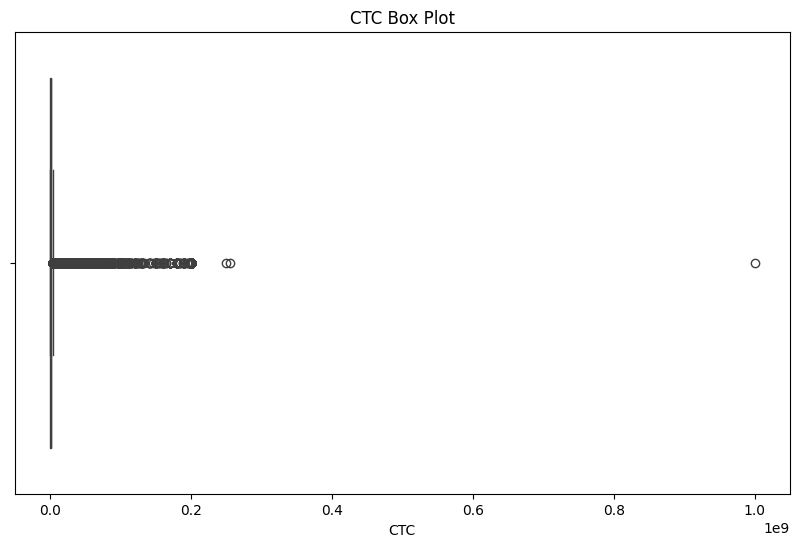

```python
plt.figure(figsize=(10, 6))
sns.boxplot(x=df['ctc'])
plt.title('CTC Box Plot')
plt.xlabel('CTC')
plt.show()
```

```python
df['CTC_zscore'] = stats.zscore(df['ctc'])

# Identify outliers (e.g., Z-score > 3 or < -3)
outliers = df[(df['CTC_zscore'] > 3) | (df['CTC_zscore'] < -3)]

print("Outliers based on Z-score:")
print("Number of outliers: ", outliers.shape[0])
print("Percentage of outliers: ", outliers.shape[0] / df.shape[0] * 100)
```

```
Outliers based on Z-score:
Number of outliers:  1499
Percentage of outliers:  0.8399547242550235
```

```python
outliers.sort_values(by='CTC_zscore', ascending=True).head()
```

|  | company_hash | email_hash | orgyear | ctc | job_position | ctc_updated_year | CTC_zscore |
| --- | --- | --- | --- | --- | --- | --- | --- |
| 168918 | ftrro evqsg | 55c7eef700e87fcd506c731be6dbbdcb79bf709678c2eb... | 2002 | 39600000 | Technical lead | 2019 | 3.006501 |
| 50457 | wgzwtznqxd | c240203d659ee5ef1a7ed9d8368ec86b7fc1d21e10701b... | 2017 | 39800000 | Others | 2020 | 3.022664 |
| 15755 | wgszxkvzn | 405acce4415219a5001f40c37ca2e5f07d433a8e769641... | 2017 | 39900000 | QA Engineer | 2020 | 3.030746 |
| 77447 | wgszxkvzn | 405acce4415219a5001f40c37ca2e5f07d433a8e769641... | 2017 | 39900000 | Support Engineer | 2020 | 3.030746 |
| 141547 | zgn vuurxwvmrt | a7b47e958b5a48f375cb74e23537b601396356545a19c5... | 2021 | 40000000 | Frontend Engineer | 2019 | 3.038828 |

```python
outliers.sort_values(by='CTC_zscore', ascending=False).head()
```

|  | company_hash | email_hash | orgyear | ctc | job_position | ctc_updated_year | CTC_zscore |
| --- | --- | --- | --- | --- | --- | --- | --- |
| 72925 | whmxw rgsxwo uqxcvnt rxbxnta | 29a71dd13adf6d2d497571a565bb3096cf66cb46cd1ece... | 2015 | 1000150000 | Frontend Engineer | 2020 | 80.635227 |
| 117948 | obvqnuqxdwgb | 5b4bed51797140db4ed52018a979db1e34cee49e27b488... | 2018 | 255555555 | Frontend Engineer | 2016 | 20.459371 |
| 3301 | aveegaxr xzntqzvnxgzvr hzxctqoxnj | 06d231f167701592a69cdd7d5c825a0f5b30f0347a4078... | 2021 | 250000000 | Frontend Engineer | 2020 | 20.010388 |
| 9220 | vayxxuv ntwyzgrgsxto ucn rna | ffc553f9b28005de1ba0ce2b546befbe7179bf0d44e2de... | 2014 | 200000000 | Co founder | 2020 | 15.969541 |
| 107466 | ytfrtnn uvwpvqa tzntquqxot | c888824e687a535d1bd2486ae28d67e414b21b09cbee61... | 2015 | 200000000 | Data Analyst | 2020 | 15.969541 |

```python
df = df[df['ctc']>=100000]
df = df[df['ctc']<=15000000]
```

```python
print("Median: ",df['ctc'].median())
print("Mean: ",df['ctc'].mean())
```

```
Median:  1000000.0
Mean:  1370185.5501391143
```

```python
# Create ctc into 3 categories
# df['ctc_category'] = pd.qcut(df['ctc'], q=3, labels=['low', 'medium', 'high'])
df['ctc_category'] = pd.cut(df['ctc'], bins=[0, 1000000, 5000000, 15000000], labels=['low', 'medium', 'high'])
```

```python
df['ctc_category'].value_counts()
```

```
ctc_category
low       91187
medium    78056
high       3277
Name: count, dtype: int64
```

```python
df.groupby('ctc_category')['ctc'].describe()
```

| ctc_category | count | mean | std | min | 25% | 50% | 75% | max |
| --- | --- | --- | --- | --- | --- | --- | --- | --- |
| low | 91187.0 | 5.955088e+05 | 2.401585e+05 | 100000.0 | 400000.0 | 600000.0 | 800000.0 | 1000000.0 |
| medium | 78056.0 | 2.017507e+06 | 8.878268e+05 | 1000008.0 | 1330000.0 | 1730000.0 | 2500000.0 | 5000000.0 |
| high | 3277.0 | 7.507861e+06 | 2.281781e+06 | 5010000.0 | 5700000.0 | 6700000.0 | 9000000.0 | 15000000.0 |

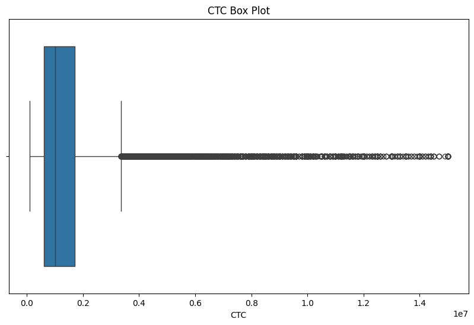

```python
plt.figure(figsize=(10, 6))
sns.boxplot(x=df['ctc'])
plt.title('CTC Box Plot')
plt.xlabel('CTC')
plt.show()
```

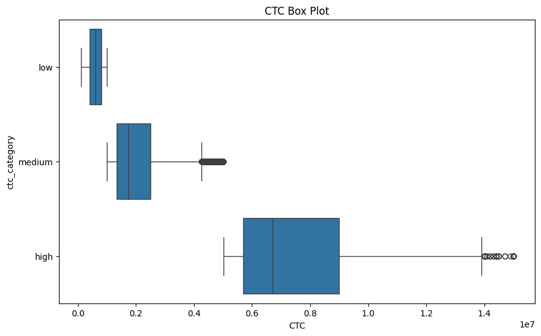

```python
plt.figure(figsize=(10, 6))
sns.boxplot(x=df['ctc'], y=df['ctc_category'])
plt.title('CTC Box Plot')
plt.xlabel('CTC')
plt.show()
```

```python
print("Organisation Year Range: ", df['orgyear'].min(), df['orgyear'].max())

# Potential outliers - orgyear < 1970 people are not likely to be working after 54 years
df[(df['orgyear']<1970) | (df['orgyear']>2024)].shape
```

```
Organisation Year Range:  0 20165
```

```
(77, 8)
```

```python
df = df[(df['orgyear']>=1970) & (df['orgyear']<=2024)]
df['year_of_experience'] = 2024 - df['orgyear']
```

### 🕵🏽‍♂️ Data Pre-processing:

- **Job Position**: The job title are cleaned manually and mapped backed to the dataset, Missing job positions are filled using KNN Imputation
- **Company Hash**: Dropped the columns where company name not provided
- **CTC**: The dataset has beeen capping based on the domain knowledge (RS1,00,000 to 1,50,00,000)
- **Organisation Year**: The Organisation year has been capped based on the fact that person might not work after 54 years
- **Year of Experience**: The column dervied from the org year

### 🕵🏽‍♂️ Insights:

- **Distribution of ctc_category**
  - Low CTC Category: 91,187 learners
  - Medium CTC Category: 78,056 learners
  - High CTC Category: 3,277 learners
- **Skewed Distribution:**
  - The distribution of learners across the ctc_category is highly skewed, with the majority falling into the low and medium categories. Only a small fraction of learners are in the high category.
- **Outliers:**
  - The presence of outliers in the medium and high categories suggests that there are learners with significantly higher CTC values than the rest. These outliers could be due to promotions, exceptional performance, or high-paying job profiles.

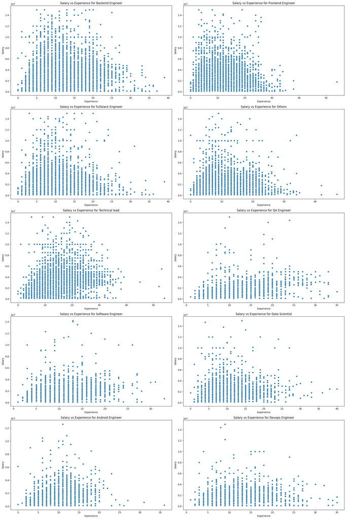

```python
# Top 10 job positions, plot the salary vs experience
top_10_job_positions = df['job_position'].value_counts().head(10).index.to_list()

fig, axes = plt.subplots(5, 2, figsize=(20, 30))
axes = axes.flatten()

for i, job in enumerate(top_10_job_positions):
    sns.scatterplot(data=df[df['job_position'] == job], x='year_of_experience', y='ctc', ax=axes[i])
    axes[i].set_title(f'Salary vs Experience for {job}')
    axes[i].set_xlabel('Experience')
    axes[i].set_ylabel('Salary')

plt.tight_layout()
plt.show()
```

```python
company_wise_summary_df = df.groupby(['company_hash', 'job_position', 'year_of_experience'])['ctc'].agg(['min', 'mean', 'median', 'max', 'count']).reset_index()
company_wise_summary_df = company_wise_summary_df[company_wise_summary_df['count'] > 0]
company_wise_summary_df.sample(5)
```

|  | company_hash | job_position | year_of_experience | min | mean | median | max | count |
| --- | --- | --- | --- | --- | --- | --- | --- | --- |
| 63643470 | wvqo24 otqcxwto uqxcvnt rxbxnta | Backend Engineer | 16 | 4500000.0 | 4500000.0 | 4500000.0 | 4500000.0 | 1 |
| 26039978 | ntqvavnv | Research Engineer | 6 | 900000.0 | 900000.0 | 900000.0 | 900000.0 | 1 |
| 54856399 | vngo ojzntr ucn rna | Data Scientist | 17 | 1800000.0 | 1800000.0 | 1800000.0 | 1800000.0 | 1 |
| 46521244 | tdutqxnton | Frontend Engineer | 7 | 2200000.0 | 2200000.0 | 2200000.0 | 2200000.0 | 1 |
| 57749595 | vuurt | Fullstack Engineer | 8 | 220000.0 | 220000.0 | 220000.0 | 220000.0 | 1 |

### Feature Creation 🥪

```python
def category_mapping(ctc, mean):
  if ctc < mean:
    return 1
  elif ctc > mean:
    return 3
  else:
    return 2
```

```python
df_grouped = df.groupby(['company_hash', 'job_position', 'year_of_experience'])['ctc'].mean().reset_index()
df_grouped.rename(columns={'ctc': 'com_pos_exp_ctc_mean'}, inplace=True)
df_grouped = df_grouped[df_grouped['com_pos_exp_ctc_mean'] > 0]
df_grouped.head()
```

|  | company_hash | job_position | year_of_experience | com_pos_exp_ctc_mean |
| --- | --- | --- | --- | --- |
| 1180 | 0 | Others | 4 | 100000.0 |
| 3192 | 0000 | Others | 7 | 300000.0 |
| 4222 | 01 ojztqsj | Android Engineer | 8 | 270000.0 |
| 4864 | 01 ojztqsj | Frontend Engineer | 13 | 830000.0 |
| 6375 | 05mz exzytvrny uqxcvnt rxbxnta | Backend Engineer | 5 | 1100000.0 |

```python
df = pd.merge(df, df_grouped, on=['company_hash', 'job_position', 'year_of_experience'], how='left')
df['designation'] = df.apply(lambda x: category_mapping(x['ctc'], x['com_pos_exp_ctc_mean']), axis=1)
df.drop(columns=['com_pos_exp_ctc_mean'], inplace=True)
```

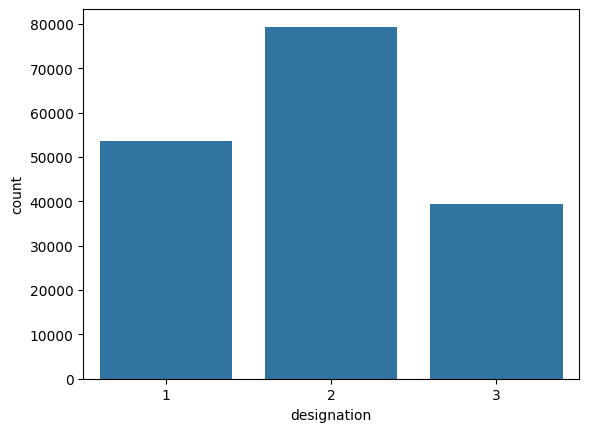

```python
sns.countplot(x='designation', data=df)
```

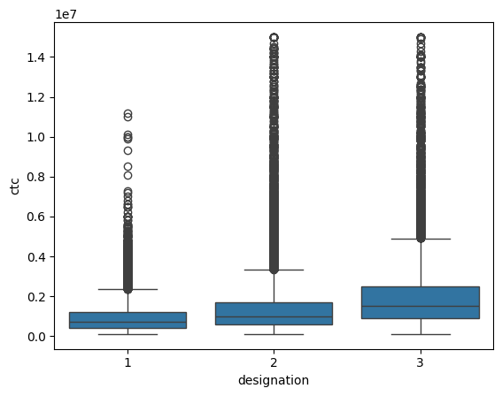

```python
sns.boxplot(x='designation', y='ctc', data=df)
```

```python
df_grouped = df.groupby(['company_hash', 'job_position'])['ctc'].mean().reset_index()
df_grouped.rename(columns={'ctc': 'com_pos_ctc_mean'}, inplace=True)
df_grouped = df_grouped[df_grouped['com_pos_ctc_mean'] > 0]
df_grouped.head()
```

|  | company_hash | job_position | com_pos_ctc_mean |
| --- | --- | --- | --- |
| 24 | 0 | Others | 100000.0 |
| 65 | 0000 | Others | 300000.0 |
| 86 | 01 ojztqsj | Android Engineer | 270000.0 |
| 99 | 01 ojztqsj | Frontend Engineer | 830000.0 |
| 130 | 05mz exzytvrny uqxcvnt rxbxnta | Backend Engineer | 1100000.0 |

```python
df = pd.merge(df, df_grouped, on=['company_hash', 'job_position'], how='left')
df['Class'] = df.apply(lambda x: category_mapping(x['ctc'], x['com_pos_ctc_mean']), axis=1)
df.drop(columns=['com_pos_ctc_mean'], inplace=True)
```

```python
df_grouped = df.groupby(['company_hash'])['ctc'].mean().reset_index()
df_grouped.rename(columns={'ctc': 'com_ctc_mean'}, inplace=True)
df_grouped = df_grouped[df_grouped['com_ctc_mean'] > 0]
df_grouped.head()
```

|  | company_hash | com_ctc_mean |
| --- | --- | --- |
| 0 | 0 | 100000.0 |
| 1 | 0000 | 300000.0 |
| 2 | 01 ojztqsj | 550000.0 |
| 3 | 05mz exzytvrny uqxcvnt rxbxnta | 1100000.0 |
| 4 | 1 | 175000.0 |

```python
df = pd.merge(df, df_grouped, on=['company_hash'], how='left')
df['Tier'] = df.apply(lambda x: category_mapping(x['ctc'], x['com_ctc_mean']), axis=1)
df.drop(columns=['com_ctc_mean'], inplace=True)
```

```python
df.sample(5)
```

|  | company_hash | email_hash | orgyear | ctc | job_position | ctc_updated_year | CTC_zscore | ctc_category | year_of_experience | designation | Class | Tier |
| --- | --- | --- | --- | --- | --- | --- | --- | --- | --- | --- | --- | --- |
| 87394 | ztdngqj uqxcvnt rxbxnta | 81f9e9d24d143e18a6b4e4ea64792038392ca1d5f32f5a... | 2019 | 550000 | Frontend Engineer | 2021 | -0.149401 | low | 5 | 2 | 2 | 2 |
| 74538 | tdwtrrtd ntwyzgrgsxto uqxcvnt rxbxnta | 6ed3aa0728ec2819fd74bb9a56e94121e9affa4ed238ce... | 2015 | 672000 | Fullstack Engineer | 2021 | -0.139541 | low | 9 | 2 | 2 | 2 |
| 27458 | ti ntwyzgrgsxw | 286e211d9ac97b8f644751c955614bdac0056f4bc3cea0... | 2017 | 1500000 | Frontend Engineer | 2021 | -0.072625 | medium | 7 | 3 | 3 | 3 |
| 42287 | ojzguojo xzw | 3ea8a32a8fa5f84afbb931771154609428bb29065d00d3... | 2020 | 380000 | Backend Engineer | 2019 | -0.163140 | low | 4 | 1 | 1 | 1 |
| 35043 | zvz | 33e1fc8bd06fc0f20c643df27a2667bcad34d2d6ba66fb... | 2015 | 2200000 | Frontend Engineer | 2021 | -0.016053 | medium | 9 | 3 | 3 | 3 |

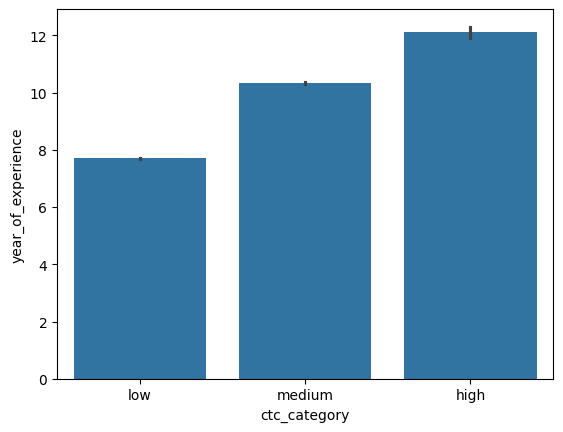

```python
sns.barplot(x='ctc_category', y='year_of_experience', data=df)
```

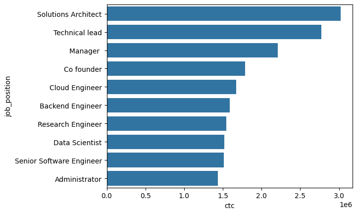

```python
# Top 10 Job positions with highest mean CTC
top_10_job_positions = df.groupby('job_position')['ctc'].mean().sort_values(ascending=False).head(10).reset_index()
sns.barplot(x='ctc', y='job_position', data=top_10_job_positions)
```

### 🕵🏽‍♂️ Insights:

Top 10 Job positions with highest mean CTC

- Solutions Architect
- Technical lead
- Manager
- Co founder
- Cloud Engineer
- Backend Engineer
- Research Engineer
- Data Scientist
- Senior Software Engineer
- Administrator

```python
df[df['Tier']==1].sort_values(by='ctc', ascending=False).head(10)
```

|  | company_hash | email_hash | orgyear | ctc | job_position | ctc_updated_year | CTC_zscore | ctc_category | year_of_experience | designation | Class | Tier |
| --- | --- | --- | --- | --- | --- | --- | --- | --- | --- | --- | --- | --- |
| 70681 | aggqavoy | 68f1fea4dbfb7ae2209664b93d5f57fb86912dbe516b37... | 2018 | 13500000 | Backend Engineer | 2020 | 0.897179 | high | 6 | 2 | 2 | 1 |
| 62401 | mqxwponttr tzntquqxoto uqxcvnt rxbxnta | 5cb0417e963b2bb218dc28cbe0c9003c39c4f2db94bb53... | 2016 | 10100000 | QA Engineer | 2019 | 0.622401 | high | 8 | 1 | 1 | 1 |
| 44445 | bsb qtogqno xzntqzvnxgzvr | 420388fd953332be671e1b0761f9af06d323382d075ecf... | 2017 | 7000000 | Fullstack Engineer | 2018 | 0.371868 | high | 7 | 2 | 2 | 1 |
| 31001 | zvnxgzvr vhonqvrxv mvzp | 2ddbc233754a1bf09fa7e92d61a5fb8fd46f3fe7908318... | 2000 | 7000000 | Technical lead | 2020 | 0.371868 | high | 24 | 2 | 2 | 1 |
| 42591 | xzagqot unt rna | 3f0f3d507158974626454f18f97876cd1f3ffe816a9757... | 2008 | 6500000 | Backend Engineer | 2020 | 0.331460 | high | 16 | 1 | 1 | 1 |
| 141931 | wgzerhtzn | d2baa62a1b611ad438f0475c2e3d88f2c6f9f3df6e56bf... | 2015 | 6000000 | Backend Engineer | 2020 | 0.291051 | high | 9 | 2 | 2 | 1 |
| 118650 | uqgutqnjshqh | b01a6b018bb4ce949e745045fae952bd9c89566480e066... | 2015 | 5820000 | Fullstack Engineer | 2020 | 0.276504 | high | 9 | 2 | 1 | 1 |
| 17465 | wvqttb | 19839c1100097c37582a06a4dbb8ec28194883f0c6b70f... | 2017 | 5600000 | Backend Engineer | 2020 | 0.258725 | high | 7 | 1 | 1 | 1 |
| 103987 | uvd vx | 9a6853551e4a153f057d06ae57bfba4a7027cdf43cf273... | 2012 | 5600000 | Backend Engineer | 2019 | 0.258725 | high | 12 | 2 | 2 | 1 |
| 103730 | xatvrg | 9a060e939ffc6ec3f5a9351ffb303ad6d064761ee66c94... | 2000 | 5440000 | Technical lead | 2020 | 0.245794 | high | 24 | 2 | 2 | 1 |

```python
# Top 10 employees of data science in each company earning more than their peers - Class 1
top_10_employees = df[(df['job_position']=='Data Scientist') & (df['Class']==1)]
top_10_employees = top_10_employees.groupby('company_hash').apply(lambda x: x.nlargest(10, 'ctc')).reset_index(drop=True)
top_10_employees.sort_values(by='company_hash')
```

|  | company_hash | email_hash | orgyear | ctc | job_position | ctc_updated_year | CTC_zscore | ctc_category | year_of_experience | designation | Class | Tier |
| --- | --- | --- | --- | --- | --- | --- | --- | --- | --- | --- | --- | --- |
| 0 | 1bs | eb213c0552effd7fb139395c7838edb8d59773a1cb57a0... | 1994 | 800000 | Data Scientist | 2019 | -0.129197 | low | 30 | 2 | 1 | 1 |
| 1 | 247vx | c35054c043f6a02da3e6f142fbcb095f8145eb521137ff... | 2014 | 2150000 | Data Scientist | 2018 | -0.020094 | medium | 10 | 2 | 1 | 3 |
| 2 | 247vx | 5f4b52a1c2539fe2e4b29a8470bc57dbace331b819a0af... | 2002 | 1440000 | Data Scientist | 2019 | -0.077474 | medium | 22 | 2 | 1 | 1 |
| 3 | 3p ntwyzgrgsxto | 583a9600d8e74d5f3f6627da6b4ff3c466bf5cfee5ae9f... | 2018 | 1200000 | Data Scientist | 2019 | -0.096870 | medium | 6 | 1 | 1 | 3 |
| 4 | 3p ntwyzgrgsxto | f3b1e96456ad8a7d9cceb3901d763252ea2f56eb2ee7f4... | 2013 | 1200000 | Data Scientist | 2019 | -0.096870 | medium | 11 | 2 | 1 | 3 |
| ... | ... | ... | ... | ... | ... | ... | ... | ... | ... | ... | ... | ... |
| 1491 | zxxn ntwyzgrgsxto | 1aa2717970a46b5d12b90932799227774dd418c842fa18... | 2012 | 2200000 | Data Scientist | 2019 | -0.016053 | medium | 12 | 2 | 1 | 3 |
| 1493 | zxxn ntwyzgrgsxto rxbxnta | 5ab93fd511bceaa6da5f855d160de306a04df9951f5978... | 2012 | 800000 | Data Scientist | 2021 | -0.129197 | low | 12 | 2 | 1 | 1 |
| 1495 | zxztrtvuo | 3027ca561b65f99da2f65bf3d85c6bb5d5687c67e69e89... | 2018 | 1370000 | Data Scientist | 2019 | -0.083131 | medium | 6 | 2 | 1 | 3 |
| 1494 | zxztrtvuo | 10d566c5fca40ffe1d133b79594d071880711ef480da9f... | 2017 | 1400000 | Data Scientist | 2019 | -0.080707 | medium | 7 | 2 | 1 | 3 |
| 1496 | zxztrtvuo | f678c67bee8cad9370f6aaf4f4cc22ffd417fd753663c6... | 2019 | 1250000 | Data Scientist | 2021 | -0.092829 | medium | 5 | 2 | 1 | 3 |

1497 rows × 12 columns

```python
# Bottom 10 employees of data science in each company earning less than their peers - Class 3
bottom_10_employees = df[(df['job_position']=='Data Scientist') & (df['Class']==3)]

# Initialize an empty DataFrame to store the results
result_df = pd.DataFrame()

# Process each company separately to avoid memory issues
for company in bottom_10_employees['company_hash'].unique():
	company_df = bottom_10_employees[bottom_10_employees['company_hash'] == company]
	bottom_10 = company_df.groupby('email_hash')['ctc'].mean().nsmallest(10).reset_index()
	bottom_10['company_hash'] = company
	result_df = pd.concat([result_df, bottom_10], ignore_index=True)

result_df = result_df[result_df['ctc'].notnull()]
result_df
```

|  | email_hash | ctc | company_hash |
| --- | --- | --- | --- |
| 0 | 63ea6962348c633656fb3e335c41356c524ed6559176a7... | 1610000.0 | xzwtag xzw |
| 1 | 001f9dbae7fccf1ef52c2187359d65c17e2897b8d211d2... | 2000000.0 | xzwtag xzw |
| 2 | a59dd7dfe78bdb896a0aa81b0fa938cd4459a99f14fa03... | 2000000.0 | xzwtag xzw |
| 10 | 0038257f6ef2580dfbc8566cc80d519819c97c2dcbddde... | 4200000.0 | rn ntwyzgrgsj otqcxwto rxbxnta |
| 20 | 70e3f9611e8afdd1184c174d0948575c6fc3dba0b1aa21... | 1050000.0 | tj |
| ... | ... | ... | ... |
| 6340 | fb5db1053d6c3d953112bd6316b9d0ebe2954dc4df3c78... | 3500000.0 | ovrtoegqwt |
| 6350 | fc0a94acd05743069d35b4dab69efd913fce055f374c8f... | 2500000.0 | ktzaqxct |
| 6360 | fc48d558c7d9abc5b8ca58c524173255b26782c15c28b9... | 2000000.0 | ihxpq |
| 6370 | fd97ee5909e0db824aaf15b5f293987a1c21272ecc491e... | 5600000.0 | jghurho xzw |
| 6380 | ffb56190424c95d9b895e9e3712cdc94c4382011357d18... | 1100000.0 | vrsgzgd ntwyzgrgsxto |

1261 rows × 3 columns

```python
# Bottom 10 employees (earning less than most of the employees in the company) - Tier 3
bottom_10_employees = df[df['Tier']==3]

# Initialize an empty DataFrame to store the results
result_df = pd.DataFrame()

# Process each company separately to avoid memory issues
for company in bottom_10_employees['company_hash'].unique():
	company_df = bottom_10_employees[bottom_10_employees['company_hash'] == company]
	bottom_10 = company_df.groupby('email_hash')['ctc'].mean().nsmallest(10).reset_index()
	bottom_10['company_hash'] = company
	result_df = pd.concat([result_df, bottom_10], ignore_index=True)

result_df = result_df[result_df['ctc'].notnull()]
result_df.sort_values(by='ctc', ascending=True).head(10)
```

|  | email_hash | ctc | company_hash |
| --- | --- | --- | --- |
| 82840 | df98a0f24fb45172e2768b53515d980f2ff5b40265d8b8... | 105000.0 | eqjo trtwnqgzxwo |
| 65050 | 979c186a6cd175b2dfbfea8e50d3bb823bb4fb9d2fd5e5... | 110000.0 | ctqxkgz fxqtrtoo |
| 33330 | 369ccf8ed6bf03c964d2822f76119ba94776b0c9ad7485... | 115000.0 | oyhnntqerj xzw |
| 15510 | 110f894dcc2dea3cbdcbd8f6e5857407184c9062920a30... | 115000.0 | wxqwrto rxet |
| 75360 | c0e59bea31301b6f14bcb8bf8ff87485ffdeac52a5d5f3... | 120000.0 | uvoohq vtqgouvwt xzw |
| 900 | 00972ad5cc152a8763c501413f1213b4c0c9cb78ed735b... | 120000.0 | ovzaxv zvnxgzvr rvmgqvngqxto |
| 83090 | e12764654b74f407aa9ddf4819030c1d9cc88e9c3f359f... | 120000.0 | uwo srgmvr uqxcvnt rxbxnta |
| 33331 | 9c8846c710a0266e74dd7d29e0d3d61f533a0da533e1ac... | 120000.0 | oyhnntqerj xzw |
| 75600 | c1b86ff295f82151e1649a338eaae941766375a74fca96... | 120000.0 | xytvqnqvaxg |
| 78290 | cc51b85d8792b7755d107504dfa1ffa6123ade28c65bd7... | 120000.0 | tuxw svbto |

```python
# Top 10 employees in each company - X department - having 5/6/7 years of experience earning more than their peers - Tier X

# Initialize an empty DataFrame to store the results
result_df = pd.DataFrame()

# Filter the relevant data
filtered_df = df[
    (df['job_position']=='Data Scientist') & (df['year_of_experience'].isin([5,6,7])) & (df['Tier']==1)
]

# Process each company separately to avoid memory issues
for company in filtered_df['company_hash'].unique():
    company_df = filtered_df[filtered_df['company_hash'] == company]
    top_10 = company_df.groupby('email_hash')['ctc'].mean().nlargest(10).reset_index()
    top_10['company_hash'] = company
    result_df = pd.concat([result_df, top_10], ignore_index=True)

result_df = result_df[result_df['ctc'].notnull()]
result_df.sort_values(by='ctc', ascending=True).head(10)
```

|  | email_hash | ctc | company_hash |
| --- | --- | --- | --- |
| 2980 | 6d50e60d562940b28dc7cd0296ea52164d272d7f5696f8... | 100000.0 | ktgnvu |
| 3321 | 7ff23b1d29cb8a2546289c567848c6f2ebbcd335af9f5c... | 100000.0 | ytrrgoxcx ogenfvqt rvmo |
| 1317 | 2cadff2fe2f39e9e4e684b95c0db58c9344fceb815c6c1... | 100000.0 | zgzt |
| 1820 | 3f1cd17776c41c8395107a340b76af3a56fe307987e271... | 103000.0 | hztburgjta |
| 400 | 0a65cc19cc9402203e3282318b9a4a127eb0b6691120cc... | 110000.0 | ihvznuyx |
| 1430 | 30b64da7d7e52c133a0e1df85c912794081242e0a792fa... | 110000.0 | vhaxmrt xzw |
| 5360 | fa24a6efde82936d129f71557a1723fcefcf0db9eee432... | 110000.0 | xzatrrxtzn |
| 3320 | a9560804241d30092205375646cd9c0df1c4a49204e678... | 112000.0 | ytrrgoxcx ogenfvqt rvmo |
| 4800 | db2c70fea469a7f1456457812fe94a01c337eb6ce75bd5... | 115000.0 | mvjtq |
| 1670 | 38b81aab25e388fb3282b99e6872365cf15b80a08bd787... | 120000.0 | xzwgqnv |

```python
# Initialize an empty DataFrame to store the results
result_df = pd.DataFrame()

# Filter the relevant data
filtered_df = df[
    (df['job_position']=='Data Scientist') & (df['year_of_experience'].isin([5,6,7])) & (df['Tier']==3)
]

# Process each company separately to avoid memory issues
for company in filtered_df['company_hash'].unique():
    company_df = filtered_df[filtered_df['company_hash'] == company]
    top_10 = company_df.groupby('email_hash')['ctc'].mean().nlargest(10).reset_index()
    top_10['company_hash'] = company
    result_df = pd.concat([result_df, top_10], ignore_index=True)

result_df = result_df[result_df['ctc'].notnull()]
result_df
```

|  | email_hash | ctc | company_hash |
| --- | --- | --- | --- |
| 0 | 009ded427ebcb5c2fb1970017a683693a7abef0fa96f5e... | 3900000.0 | eqvwnvr vzvrjnxwo |
| 1 | ea7eb74cbbabcb83aa2f66891c6deb847a603c2a40535f... | 2800000.0 | eqvwnvr vzvrjnxwo |
| 2 | 10dc906ae6fedaac7e16b0dd71356be39e2136911990a9... | 2380000.0 | eqvwnvr vzvrjnxwo |
| 3 | 3fdfb9b1014a0d22fd5fa9d5c7a686a31a16a933eda144... | 2300000.0 | eqvwnvr vzvrjnxwo |
| 4 | aedf693542ac76087cb458cfc66154382568d02f0d6acb... | 2200000.0 | eqvwnvr vzvrjnxwo |
| ... | ... | ... | ... |
| 3890 | fba008a8a93022172e3adfa293d9ce0f4d70267afa373d... | 500000.0 | vuurxta vx |
| 3900 | fbac8d7a3768fdb72d929a641d9ec1c307d35487bd0aad... | 1500000.0 | bvyxzaqv wgbcxcv ntwyzgrgsxto rna |
| 3910 | fbb5702400e9542c9ddcbb561189dafec71131f8458856... | 1050000.0 | bvqgugon |
| 3920 | fc48d558c7d9abc5b8ca58c524173255b26782c15c28b9... | 2000000.0 | ihxpq |
| 3930 | ffc974693a2bfd0326c707d8460d6783861a9497e538e2... | 1700000.0 | atrgxnnt xzaxv |

566 rows × 3 columns

```python
# Initialize an empty DataFrame to store the results
result_df = pd.DataFrame()

# Filter the relevant data
filtered_df = df[
    (df['job_position']=='Data Scientist') & (df['year_of_experience'].isin([5,6,7])) & (df['Tier']==2)
]

# Process each company separately to avoid memory issues
for company in filtered_df['company_hash'].unique():
    company_df = filtered_df[filtered_df['company_hash'] == company]
    top_10 = company_df.groupby('email_hash')['ctc'].mean().nlargest(10).reset_index()
    top_10['company_hash'] = company
    result_df = pd.concat([result_df, top_10], ignore_index=True)

result_df = result_df[result_df['ctc'].notnull()]
result_df
```

|  | email_hash | ctc | company_hash |
| --- | --- | --- | --- |
| 0 | 013a80ea3b5799eb374ec5dd94d3c84579ba0b44293258... | 400000.0 | mxsnvuu vzvrjnxwo |
| 10 | 01e291d69add1b6340ff19d8f4cb396ffb2a7a58c5b82b... | 900000.0 | avnv owxtzwt nqvxztt vn tafxogq |
| 20 | 01e29469795e1395f058e33226e15b1a32d335e92ac5bf... | 1800000.0 | tuxex ntwyzgrgsxto ucn rna |
| 30 | 0272dcd1909235f14140851a86a1bfb22098d4c71bd0f7... | 1500000.0 | vqjv |
| 40 | 02d70fdfcde30937fa1953b7e17b4f20b6bb57de684ec5... | 700000.0 | vqjzs |
| ... | ... | ... | ... |
| 3600 | fa57641000b5bb092b93eb2d5b615275b550045aece5b9... | 750000.0 | bvszv xzegntwy v ihtoo wgbuvzj |
| 3610 | fb62ad17e33d701e2369045284190ff75e7e795eba1dc5... | 620000.0 | vae avnv owxtzwt uqxcvnt rxbxnta |
| 3620 | fc0472f7b02f8569d8a368972f2f6f99e509a961e9078e... | 1980000.0 | l u bgqsvz otqcxwto xzaxv ucn rna |
| 3630 | ff7bace89454b0965e40533aa5b7f904dba9c496b1a1f2... | 1019999.0 | xuqtaxwnwgszxnxct ntwyzgrgsxto ucn rna |
| 3640 | ffa4d3df725be3628607627e575feac064a1e98506dc19... | 900000.0 | qtmxn |

366 rows × 3 columns

```python
# Top 10 companies (based on their CTC)
top_10_companies = df.groupby('company_hash')['ctc'].mean().sort_values(ascending=False).head(10).reset_index()
top_10_companies
```

|  | company_hash | ctc |
| --- | --- | --- |
| 0 | mqvojo | 15000000.0 |
| 1 | qtuogr | 15000000.0 |
| 2 | ihxu | 15000000.0 |
| 3 | cyhm | 15000000.0 |
| 4 | qtvrotre | 15000000.0 |
| 5 | hzxctqoxnj ge ntdvo vn avrrvo | 15000000.0 |
| 6 | vnox xzw | 14400000.0 |
| 7 | ogenfvqt tzsxzttqxzs | 14400000.0 |
| 8 | gqvmvot ogrhnxgzo | 14400000.0 |
| 9 | xnc | 14000000.0 |

```python
# Top 2 positions in every company (based on their CTC)
top_2_positions = df.groupby(['company_hash', 'job_position'])['ctc'].mean().groupby('company_hash', group_keys=False).nlargest(2).reset_index()
top_2_positions.groupby('company_hash')['job_position'].apply(list).reset_index()
```

|  | company_hash | job_position |
| --- | --- | --- |
| 0 | 0 | [Others, Accounting] |
| 1 | 0000 | [Others, Accounting] |
| 2 | 01 ojztqsj | [Frontend Engineer, Android Engineer] |
| 3 | 05mz exzytvrny uqxcvnt rxbxnta | [Backend Engineer, Accounting] |
| 4 | 1 | [Others, Frontend Engineer] |
| ... | ... | ... |
| 37294 | zyvzwt wgzohrnxzs tzsxzttqo | [Frontend Engineer, Accounting] |
| 37295 | zz | [Others, Frontend Engineer] |
| 37296 | zzb ztdnstz vacxogqj ucn rna | [Fullstack Engineer, Accounting] |
| 37297 | zzgato | [Frontend Engineer, Accounting] |
| 37298 | zzzbzb | [Others, Accounting] |

37299 rows × 2 columns

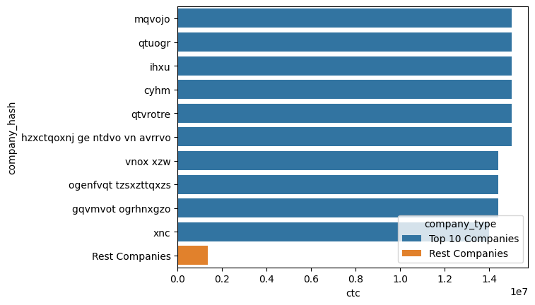

```python
# compare the mean CTC of the top 10 companies with the mean CTC of the rest of the companies
top_10_companies = df.groupby('company_hash')['ctc'].mean().sort_values(ascending=False).head(10).reset_index()
top_10_companies['company_type'] = 'Top 10 Companies'

rest_companies = df[~df['company_hash'].isin(top_10_companies['company_hash'])]
rest_companies_mean_ctc = rest_companies['ctc'].mean()
rest_companies = pd.DataFrame({'company_hash': ['Rest Companies'], 'ctc': [rest_companies_mean_ctc], 'company_type': ['Rest Companies']})

companies_df = pd.concat([top_10_companies, rest_companies], ignore_index=True)
sns.barplot(x='ctc', y='company_hash', data=companies_df, hue='company_type')
```

```python
df.sample(5)
```

|  | company_hash | email_hash | orgyear | ctc | job_position | ctc_updated_year | CTC_zscore | ctc_category | year_of_experience | designation | Class | Tier |
| --- | --- | --- | --- | --- | --- | --- | --- | --- | --- | --- | --- | --- |
| 150583 | kxusg | dfa84e64857e65fb415417939f6393f520462cae373a4f... | 2014 | 1700000 | Manager | 2019 | -0.056461 | medium | 10 | 2 | 1 | 3 |
| 112825 | rtznqv | a787c58d015cfb352a1d4244d52da45738169326b999f2... | 2018 | 660000 | Backend Engineer | 2021 | -0.140511 | low | 6 | 2 | 2 | 3 |
| 62856 | exwg | 5d6d61c7f0a99ff6fc574b8ed0263eb3132d060cfc575e... | 2010 | 2000000 | Backend Engineer | 2019 | -0.032216 | medium | 14 | 3 | 3 | 3 |
| 25746 | uqvbvnx ntwyzgrgsxto uqxcvnt rxbxnta | 25dfdf2bbb2b5f45fb5f82ed2d7620f7b25806431df906... | 2014 | 600000 | QA Engineer | 2019 | -0.145360 | low | 10 | 2 | 2 | 1 |
| 133659 | whqgej | c682f7df08f21debe505a5eaca754e05b79b5a6a17e060... | 2010 | 700000 | Frontend Engineer | 2019 | -0.137278 | low | 14 | 2 | 1 | 1 |

### Data preparation for Modelling 🤼

```python
scaled_df = df.copy()
```

```python
# Standardize Numerical Data
numerical_cols = ['ctc', 'year_of_experience', 'orgyear','ctc_updated_year']
scaler = StandardScaler()
scaled_df[numerical_cols] = scaler.fit_transform(scaled_df[numerical_cols])

# Frequency Encoding for company_hash
company_hash_frequency = scaled_df['company_hash'].value_counts().to_dict()
scaled_df['company_hash_encoded'] = scaled_df['company_hash'].map(company_hash_frequency)

# Encode Other Categorical Data
categorical_cols = ['job_position', 'ctc_category', 'Class', 'Tier']
encoder = OneHotEncoder(sparse_output=False)
encoded_categorical_data = encoder.fit_transform(scaled_df[categorical_cols])
encoded_categorical_df = pd.DataFrame(encoded_categorical_data, columns=encoder.get_feature_names_out(categorical_cols))

# Concatenate the encoded categorical data with the original DataFrame
scaled_df = pd.concat([scaled_df, encoded_categorical_df], axis=1)

# Drop the original categorical columns
scaled_df.drop(columns=categorical_cols, inplace=True)
scaled_df.drop(columns=['company_hash','CTC_zscore','email_hash'], inplace=True)
```

```python
scaled_df.sample(5)
```

|  | orgyear | ctc | ctc_updated_year | year_of_experience | designation | company_hash_encoded | job_position_Accounting | job_position_Administrator | job_position_Advisory | job_position_Analyst | ... | job_position_iOS Engineer | ctc_category_high | ctc_category_low | ctc_category_medium | Class_1 | Class_2 | Class_3 | Tier_1 | Tier_2 | Tier_3 |
| --- | --- | --- | --- | --- | --- | --- | --- | --- | --- | --- | --- | --- | --- | --- | --- | --- | --- | --- | --- | --- | --- |
| 128407 | 0.465676 | 0.581414 | 1.115702 | -0.465676 | 3 | 1459 | 0.0 | 0.0 | 0.0 | 0.0 | ... | 0.0 | 0.0 | 0.0 | 1.0 | 0.0 | 0.0 | 1.0 | 0.0 | 0.0 | 1.0 |
| 132177 | 0.230061 | -0.665794 | 1.115702 | -0.230061 | 2 | 2 | 0.0 | 0.0 | 0.0 | 0.0 | ... | 0.0 | 0.0 | 1.0 | 0.0 | 0.0 | 1.0 | 0.0 | 0.0 | 0.0 | 1.0 |
| 142402 | -1.890475 | 0.252396 | -0.388753 | 1.890475 | 2 | 52 | 0.0 | 0.0 | 0.0 | 0.0 | ... | 0.0 | 0.0 | 0.0 | 1.0 | 0.0 | 0.0 | 1.0 | 0.0 | 0.0 | 1.0 |
| 144312 | -0.712400 | -0.589278 | 1.115702 | 0.712400 | 1 | 41 | 0.0 | 0.0 | 0.0 | 0.0 | ... | 0.0 | 0.0 | 1.0 | 0.0 | 1.0 | 0.0 | 0.0 | 1.0 | 0.0 | 0.0 |
| 108296 | -0.948015 | -0.359730 | -1.893209 | 0.948015 | 3 | 288 | 0.0 | 0.0 | 0.0 | 0.0 | ... | 0.0 | 0.0 | 1.0 | 0.0 | 0.0 | 0.0 | 1.0 | 1.0 | 0.0 | 0.0 |

5 rows × 56 columns

#### Model Building

##### KMeans Clustering 🏘️

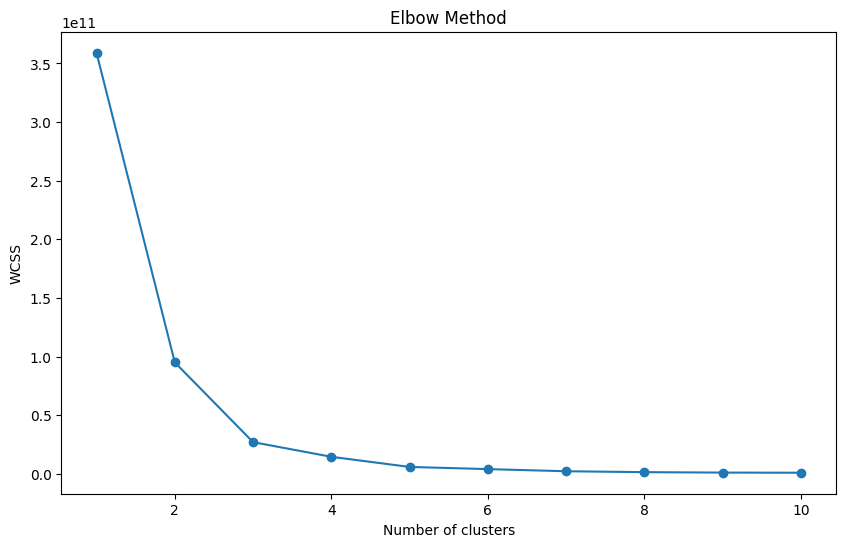

```python
X = scaled_df.values

# Elbow Method
wcss = []
for i in range(1, 11):
    kmeans = KMeans(n_clusters=i, random_state=42)
    kmeans.fit(X)
    wcss.append(kmeans.inertia_)

plt.figure(figsize=(10, 6))
plt.plot(range(1, 11), wcss, marker='o')
plt.title('Elbow Method')
plt.xlabel('Number of clusters')
plt.ylabel('WCSS')
plt.show()
```

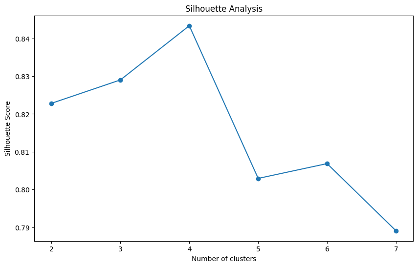

```python
# Silhouette Analysis
silhouette_scores = []
for i in range(2, 8):
    kmeans = KMeans(n_clusters=i, random_state=42)
    kmeans.fit(X)
    score = silhouette_score(X, kmeans.labels_)
    silhouette_scores.append(score)

plt.figure(figsize=(10, 6))
plt.plot(range(2, 8), silhouette_scores, marker='o')
plt.title('Silhouette Analysis')
plt.xlabel('Number of clusters')
plt.ylabel('Silhouette Score')
plt.show()
```

### 🕵🏽‍♂️ Elbow Method and Silhouette Analysis

- **Elbow Method:** Suggests a potential optimal number of clusters at 3, as there is a noticeable drop in WCSS.
- **Silhouette Analysis:** Indicates that 4 clusters have the highest silhouette score, suggesting the best-defined clusters.

Considering both methods, the optimal number of clusters appears to be 4 clusters. While the Elbow Method suggests 3 clusters, the Silhouette Analysis strongly indicates that 4 clusters provide the best-defined clusters. Therefore, 4 clusters are likely the most appropriate choice for this dataset.

```python
kmeans = KMeans(n_clusters = 4, random_state = 3)
kmeans.fit(X)

scaled_df['kM_cluster'] = kmeans.labels_
scaled_df['kM_cluster'].value_counts()
```

```
kM_cluster
1    138028
3     20824
2      7189
0      6402
Name: count, dtype: int64
```

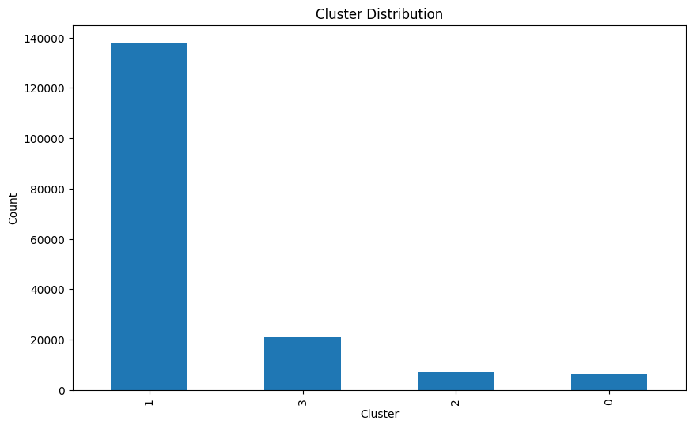

```python
# Distribution of each cluster
plt.figure(figsize=(10, 6))
scaled_df['kM_cluster'].value_counts().plot(kind='bar')
plt.title('Cluster Distribution')
plt.xlabel('Cluster')
plt.ylabel('Count')
plt.show()
```

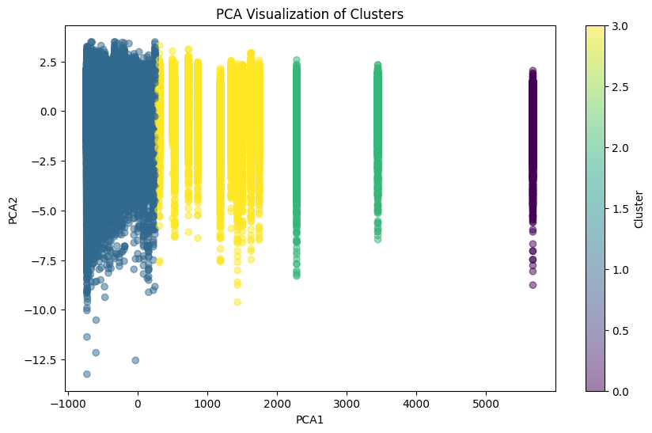

```python
import matplotlib.pyplot as plt
from sklearn.decomposition import PCA

# Perform PCA to reduce dimensionality to 2D for visualization
pca = PCA(n_components=2)
pca_result = pca.fit_transform(scaled_df.drop(columns=['kM_cluster']))

# Create a DataFrame with PCA results and cluster labels
pca_df = pd.DataFrame(pca_result, columns=['PCA1', 'PCA2'])
pca_df['Cluster'] = scaled_df['kM_cluster']

# Plot the PCA results
plt.figure(figsize=(10, 6))
plt.scatter(pca_df['PCA1'], pca_df['PCA2'], c=pca_df['Cluster'], cmap='viridis', alpha=0.5)
plt.title('PCA Visualization of Clusters')
plt.xlabel('PCA1')
plt.ylabel('PCA2')
plt.colorbar(label='Cluster')
plt.show()
```

```python
df['kM_cluster'] = kmeans.labels_
print('-'*5, 'Cluster Analysis', '-'*5)
print(df.groupby('kM_cluster')['year_of_experience'].mean())
print('-'*10, 'Cluster Mean', '-'*10)
print(df.groupby('kM_cluster')['ctc'].mean())
```

```
----- Cluster Analysis -----
kM_cluster
0    6.785848
1    9.271662
2    7.678398
3    8.141087
Name: year_of_experience, dtype: float64
---------- Cluster Mean ----------
kM_cluster
0    6.138651e+05
1    1.418803e+06
2    1.366223e+06
3    1.281431e+06
Name: ctc, dtype: float64
```

```python
print('-'*10, 'Cluster Median', '-'*10)
print(df.groupby('kM_cluster')['ctc'].median())
print('-'*10, 'Cluster Minimum', '-'*10)
print(df.groupby('kM_cluster')['ctc'].min())
print('-'*10, 'Cluster Maximum', '-'*10)
print(df.groupby('kM_cluster')['ctc'].max())
```

```
---------- Cluster Median ----------
kM_cluster
0     450000.0
1    1040000.0
2     700000.0
3     819999.0
Name: ctc, dtype: float64
---------- Cluster Minimum ----------
kM_cluster
0    100000
1    100000
2    100000
3    100000
Name: ctc, dtype: int32
---------- Cluster Maximum ----------
kM_cluster
0    11200000
1    15000000
2    14700000
3    15000000
Name: ctc, dtype: int32
```

### Interpretation 🕵🏽‍♂️

**Cluster 0:**

- **Median CTC:** This cluster has the lowest median CTC at 450,000, indicating that the majority of individuals in this cluster have relatively lower salaries compared to other clusters.
- **Range:** The CTC ranges from 100,000 to 11,200,000, showing a significant spread. This suggests that while the median is low, there are some high earners within this cluster.

**Cluster 1:**

- **Median CTC:** This cluster has the highest median CTC at 1,040,000, indicating that the majority of individuals in this cluster have higher salaries compared to other clusters.
- **Range:** The CTC ranges from 100,000 to 15,000,000, indicating a wide spread. This cluster includes both high earners and individuals with lower salaries.

**Cluster 2:**

- **Median CTC:** This cluster has a median CTC of 700,000, which is moderate compared to other clusters.
- **Range:** The CTC ranges from 100,000 to 14,700,000, showing a wide spread. This cluster includes a mix of individuals with varying salary levels.

**Cluster 3:**

- **Median CTC:** This cluster has a median CTC of 819,999, which is slightly higher than Cluster 2 but lower than Cluster 1.
- **Range:** The CTC ranges from 100,000 to 15,000,000, indicating a wide spread. This cluster also includes a mix of individuals with varying salary levels.

```python
scaled_df.shape
```

```
(172443, 57)
```

### Hierarchical Clustering

```python
sampled_df = scaled_df.sample(55000)
sampled_df = sampled_df.drop(columns=['kM_cluster'])
```

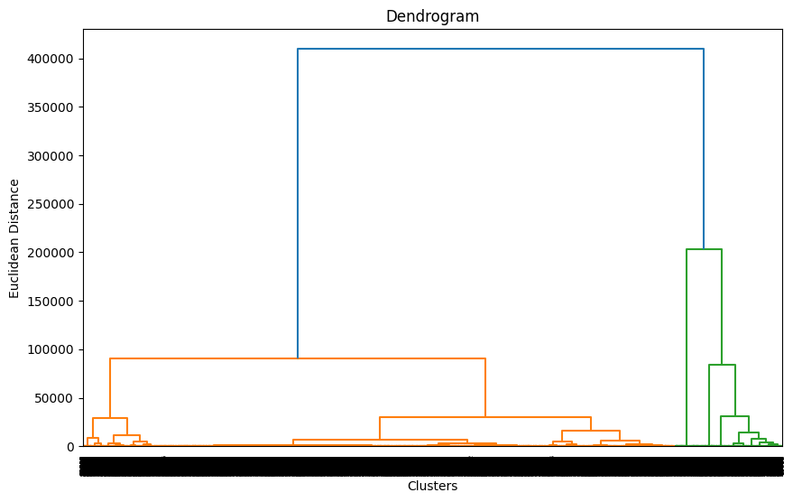

```python
# Hierarchical Clustering - Dendrogram

cluster_0 = sampled_df.values
Z = linkage(cluster_0, method='ward')

plt.figure(figsize=(10, 6))
dendrogram(Z)
plt.title('Dendrogram')
plt.xlabel('Clusters')
plt.ylabel('Euclidean Distance')
plt.show()
```

```python
# Cut the dendrogram to form 3 clusters
num_clusters = 3
clusters = fcluster(Z, num_clusters, criterion='maxclust')

# Add the cluster labels to the subset DataFrame
sampled_df['Cluster'] = clusters
```

### Actionable Insights and Recommendations 🕵🏽‍♂️

- **Targeted Interventions:**
  - For learners in the low category, consider providing additional training and resources to help them move to higher CTC categories.
  - For learners in the medium category, focus on career development and opportunities for promotions to help them achieve higher CTC values.
  - For learners in the high category, provide support for continued professional growth and retention strategies to maintain their high performance.
- **Role Transition:**
  - For learners experiencing the plateau effect, consider transitioning to higher-level roles (e.g., from software engineer to technical lead) to achieve further salary growth.
- **Negotiation Skills:**
  - Equip learners with negotiation skills to help them secure better salaries, especially when they have significant experience or specialized skills.